# Development of Iridescence due to Exposure to Estrogen

Coley Tosto

2023-03-06

```r
library(car)
library(knitr)
library(kableExtra)
library(tidyverse)
library(ggplot2)
library(magick)
library(cowplot)
```

```r
estrogen_data <- read.csv("processed_data/estrogen.csv")
estrogen_data$Exposure <- as.factor(estrogen_data$Exposure)

mvfiri <- read.csv("processed_data/mvfiri.csv")
```

For this analysis we are trying to see if there is a significant increase in the amount of iridescence on male pipefish after exposure to synthetic estrogen.

### Exploring Morphemetrics

Here we are testing to ensure that the sizes of the males used in the control versus the estrogen-exposed groups did not significantly differ in size. A difference in size may skew the way that males are affected by synthetic estrogen.

#### Summary Table

Summarized data of morphometrics including the mean and SD for each variable

| Exposure | Length | SD | Depth Before | SD | Depth After | SD | SVL | SD |
| --- | --- | --- | --- | --- | --- | --- | --- | --- |
| Control | 94.173 | 9.319087 | 3.54820 | 0.5171583 | 3.60280 | 0.5567789 | 36.42080 | 2.398808 |
| Estrogen | 93.179 | 11.345975 | 3.96675 | 0.6617548 | 4.63325 | 0.7232541 | 36.28825 | 4.062583 |

#### Length (mm)

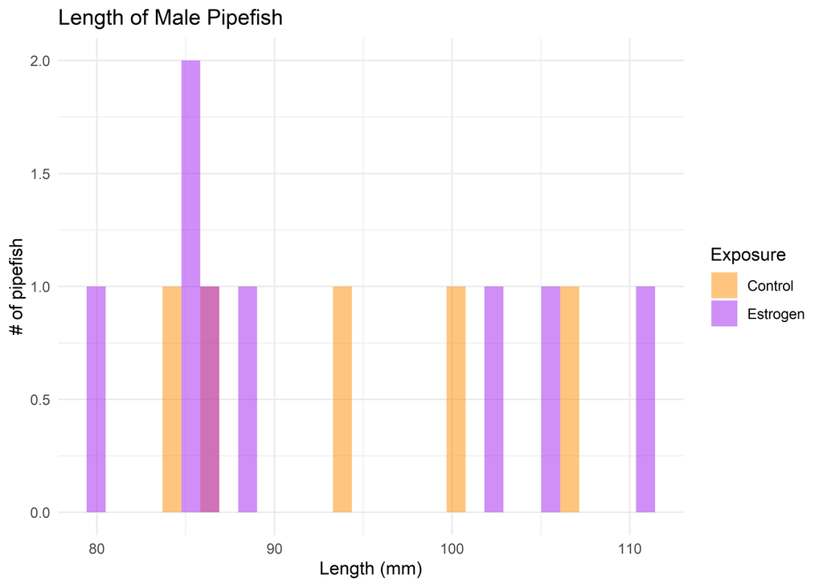

Histogram of the lengths of the male pipefish in mm

#### Depth before Exposure (mm)

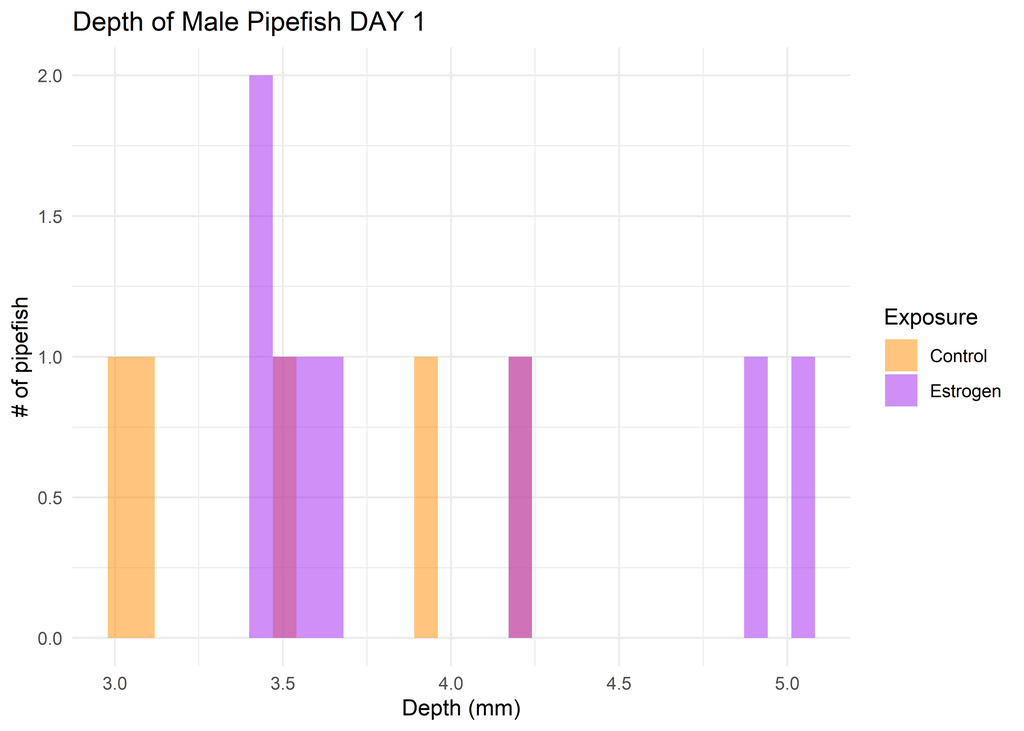

Histogram of the depths of the pipefish prior to the experiment starting

#### Depth after Exposure (mm)

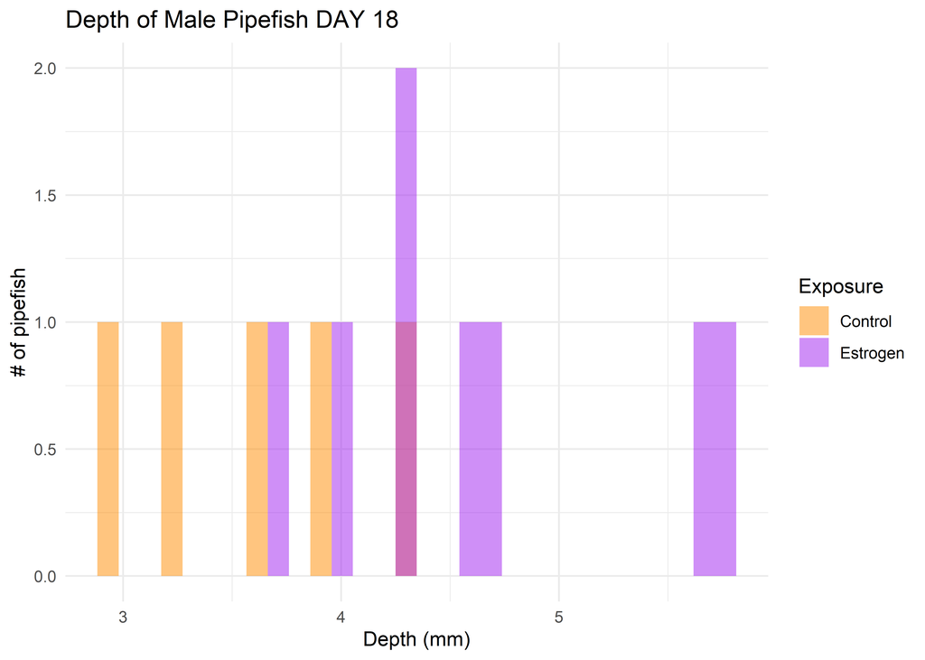

Histogram of the depths of the pipefish at the end of the 18 days

#### Snout-vent Length (mm)

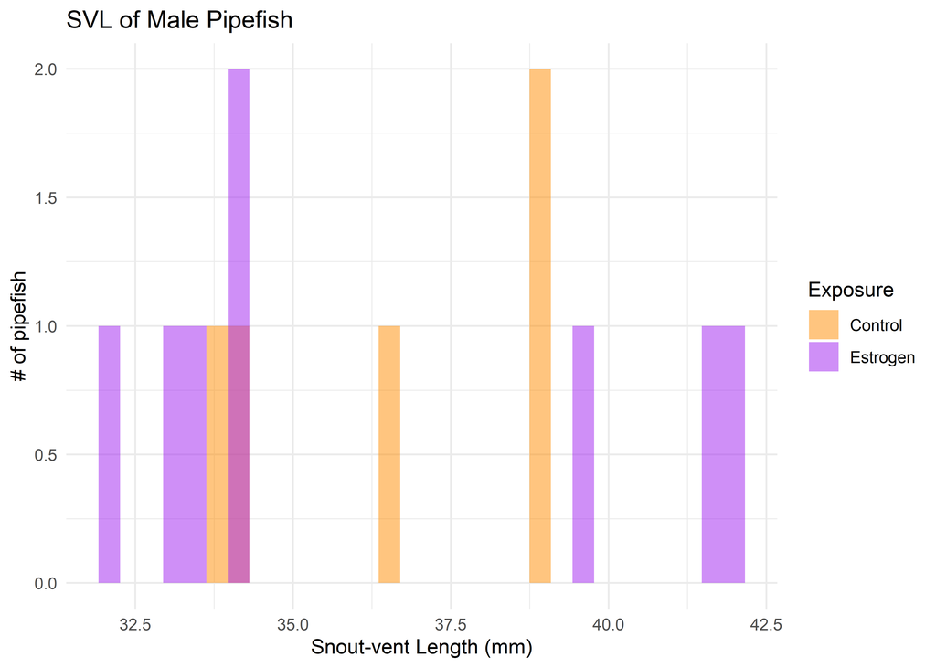

Histogram of the snout-vent length of the male piepfish

#### Analysis

```r
##Length
leveneTest(length~Exposure, estrogen_data)
```

```
## Levene's Test for Homogeneity of Variance (center = median)
##       Df F value Pr(>F)
## group  1  0.1386 0.7167
##       11
```

```r
t.test(length~Exposure, data = estrogen_data) #No sig. difference
```

```
##
##  Welch Two Sample t-test
##
## data:  length by Exposure
## t = 0.17184, df = 9.9599, p-value = 0.867
## alternative hypothesis: true difference in means between group Control and group Estrogen is not equal to 0
## 95 percent confidence interval:
##  -11.90172  13.88972
## sample estimates:
##  mean in group Control mean in group Estrogen
##                 94.173                 93.179
```

```r
##Depth day 1
leveneTest(depth_before~Exposure, estrogen_data)
```

```
## Levene's Test for Homogeneity of Variance (center = median)
##       Df F value Pr(>F)
## group  1   0.091 0.7686
##       11
```

```r
t.test(depth_before~Exposure, data = estrogen_data) #No sig. difference
```

```
##
##  Welch Two Sample t-test
##
## data:  depth_before by Exposure
## t = -1.2723, df = 10.245, p-value = 0.2314
## alternative hypothesis: true difference in means between group Control and group Estrogen is not equal to 0
## 95 percent confidence interval:
##  -1.1492032  0.3121032
## sample estimates:
##  mean in group Control mean in group Estrogen
##                3.54820                3.96675
```

```r
##Depth day 18
leveneTest(depth_after~Exposure, estrogen_data)
```

```
## Levene's Test for Homogeneity of Variance (center = median)
##       Df F value Pr(>F)
## group  1  0.2714 0.6127
##       11
```

```r
t.test(depth_after~Exposure, estrogen_data) #Sig. difference
```

```
##
##  Welch Two Sample t-test
##
## data:  depth_after by Exposure
## t = -2.8871, df = 10.324, p-value = 0.0157
## alternative hypothesis: true difference in means between group Control and group Estrogen is not equal to 0
## 95 percent confidence interval:
##  -1.8223316 -0.2385684
## sample estimates:
##  mean in group Control mean in group Estrogen
##                3.60280                4.63325
```

```r
##SVL
leveneTest(SVL~Exposure, estrogen_data)
```

```
## Levene's Test for Homogeneity of Variance (center = median)
##       Df F value Pr(>F)
## group  1  0.5716 0.4655
##       11
```

```r
t.test(SVL~Exposure, estrogen_data) #No sig. difference
```

```
##
##  Welch Two Sample t-test
##
## data:  SVL by Exposure
## t = 0.073937, df = 10.999, p-value = 0.9424
## alternative hypothesis: true difference in means between group Control and group Estrogen is not equal to 0
## 95 percent confidence interval:
##  -3.813315  4.078415
## sample estimates:
##  mean in group Control mean in group Estrogen
##               36.42080               36.28825
```

No significant difference in the sizes of the males (including length, depth, and SVL) in the control group versus the exposure group when they entered the experiment. However, after the 18-day period males that were exposed to estrogen became significantly deeper than males in the control group.

### Data Exploration

#### Summary Table

Summarized Data

| Exposure | change_iri_mean | change_iri_SD |
| --- | --- | --- |
| Control | -0.530940 | 0.6433945 |
| Estrogen | 2.489475 | 2.1256740 |

#### Histogram

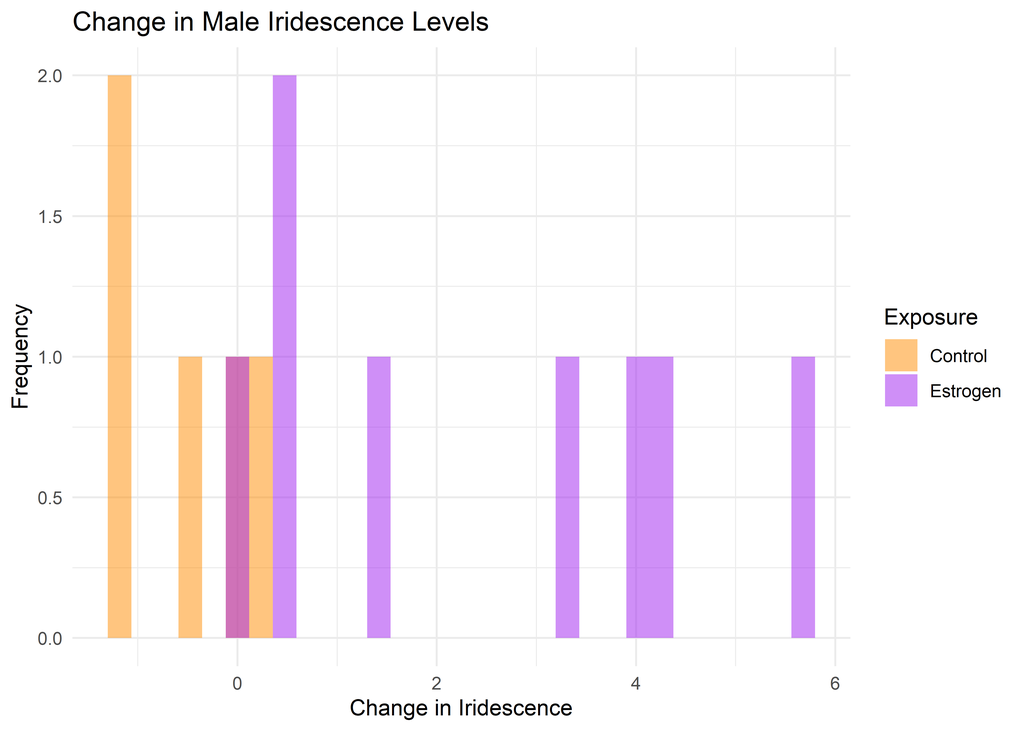

Histogram of change in iridescence in males exposed vs unexposed to estrogen after 18 days

### Analysis

```r
leveneTest(change_iri~Exposure, estrogen_data)
```

```
## Levene's Test for Homogeneity of Variance (center = median)
##       Df F value   Pr(>F)
## group  1  15.448 0.002351 **
##       11
## ---
## Signif. codes:  0 '***' 0.001 '**' 0.01 '*' 0.05 '.' 0.1 ' ' 1
```

```r
wilcox.test(change_iri~Exposure, data = estrogen_data)
```

```
##
##  Wilcoxon rank sum exact test
##
## data:  change_iri by Exposure
## W = 1, p-value = 0.003108
## alternative hypothesis: true location shift is not equal to 0
```

Signifcant different between how much iridescence was developed over the 18 day period between males that were exposed to synthetic estrogen, and those that were not exposed. Now we want to see how the level of iridescence found on males that were exposed to estrogen compared to iridescence present on females from the same location.

```r
wilcox.test(Iridescence~Sex, data = mvfiri)
```

```
##
##  Wilcoxon rank sum exact test
##
## data:  Iridescence by Sex
## W = 125, p-value = 0.0003476
## alternative hypothesis: true location shift is not equal to 0
```

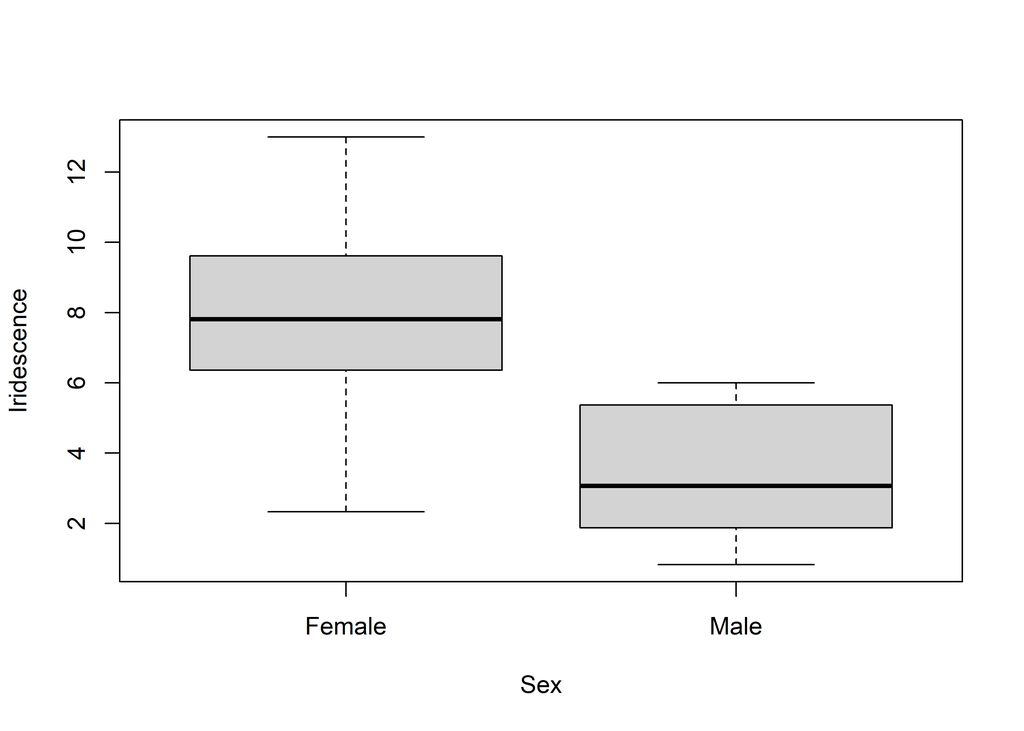

```r
boxplot(Iridescence~Sex, data = mvfiri,
        ylab = "Iridescence", xlab = "Sex")
```

There is a significatn difference between the two as females do possess more iridescence. However, many of the iridescence vales for the exposed males (0.8232 - 5.9987) fall within the range of iridescence (2.3285 - 13.0014) found on wild caught females.

### Create Figure

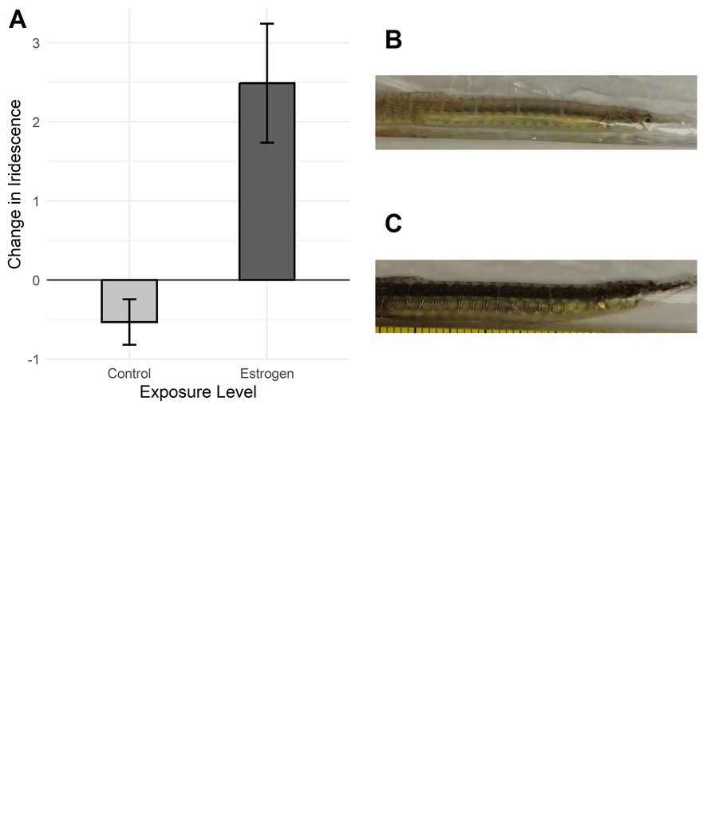